# hw1

Yichen Lin 9085319599

2023-02-19

## Reshaping practice

1. Reshaping practice The following parts ask you to provide R code that transforms one dataset (I) into another (II).
   1. Regional murder rates: Turn [I](https://uwmadison.box.com/shared/static/h4gau9heqy3uue9rmpq9b55s3kw37zd8.csv) into [II](https://uwmadison.box.com/shared/static/shy7od3ydtiqu3lmqvy4nbi17qkg2ys4.csv).

```r
murder_rate1 <- read.csv("https://uwmadison.box.com/shared/static/h4gau9heqy3uue9rmpq9b55s3kw37zd8.csv")
murder_rate2 <- read.csv("https://uwmadison.box.com/shared/static/shy7od3ydtiqu3lmqvy4nbi17qkg2ys4.csv")
murder_rate1
```

```
##                   state abb        region population total
## 1               Alabama  AL         South    4779736   135
## 2                Alaska  AK          West     710231    19
## 3               Arizona  AZ          West    6392017   232
## 4              Arkansas  AR         South    2915918    93
## 5            California  CA          West   37253956  1257
## 6              Colorado  CO          West    5029196    65
## 7           Connecticut  CT     Northeast    3574097    97
## 8              Delaware  DE         South     897934    38
## 9  District of Columbia  DC         South     601723    99
## 10              Florida  FL         South   19687653   669
## 11              Georgia  GA         South    9920000   376
## 12               Hawaii  HI          West    1360301     7
## 13                Idaho  ID          West    1567582    12
## 14             Illinois  IL North Central   12830632   364
```

[output cut: 37 more lines]

```r
murder_rate1 %>%
  group_by(region) %>%
  summarise(murders = sum(total),population = sum(population)) %>%
  mutate(murder_rate = murders / population) %>%
  arrange(.,murder_rate)
```

```
## # A tibble: 4 × 4
##   region        murders population murder_rate
##   <chr>           <int>      <int>       <dbl>
## 1 Northeast        1469   55317240   0.0000266
## 2 West             1911   71945553   0.0000266
## 3 North Central    1828   66927001   0.0000273
## 4 South            4195  115674434   0.0000363
```

```r
murder_rate2
```

```
##          region murders population  murder_rate
## 1     Northeast    1469   55317240 2.655592e-05
## 2          West    1911   71945553 2.656175e-05
## 3 North Central    1828   66927001 2.731334e-05
## 4         South    4195  115674434 3.626558e-05
```

2. Antiobitics and bacteria. Turn [I](https://uwmadison.box.com/shared/static/bq4afq9kl2zn9qlb89q2rxhrrv73iuil.csv) into [II](https://uwmadison.box.com/shared/static/gmzul7bp78o6kwtutl73hkiyxea4dr21.csv)

```r
data1 <- read.csv("https://uwmadison.box.com/shared/static/bq4afq9kl2zn9qlb89q2rxhrrv73iuil.csv")
data2 <- read.csv("https://uwmadison.box.com/shared/static/gmzul7bp78o6kwtutl73hkiyxea4dr21.csv")
data1
```

```
##     sample      antibiotic Unc05qi6 Unc06af7 Unc06bhm Unc06g1h Unc06grq
## 1       D1 Antibiotic-free        0       11       79      108      791
## 2       D2 Antibiotic-free        0       31     1413      192     1616
## 3       D3 Antibiotic-free        0       23      915      165     1323
## 4       D4 Antibiotic-free        0       31     1366      170     1846
## 5       D5 Antibiotic-free        0       26      689      135     2314
## 6       D6 Antibiotic-free        0      175      776      310     2244
## 7       D7 Antibiotic-free        0      181      609      235     1652
## 8       D8 Antibiotic-free        1        3      470       30      347
## 9       D9 Antibiotic-free        0      121      309      159      837
## 10     D10 Antibiotic-free        0       48       74       56      500
## 11     D11 Antibiotic-free        0        0      160       59     1371
## 12     D12      Antibiotic        0        3     1230       38      424
## 13     D13      Antibiotic        0       85     1156      123      576
## 14     D14      Antibiotic        0        4     2744       68      103
```

[output cut: 311 more lines]

```r
data1 %>%
  pivot_longer(
    cols = Unc05qi6:Unc09fy6,
    names_to = 'species',
    values_to = 'value',
    values_drop_na = TRUE
  ) %>%
  mutate(ind = str_extract(`sample`,"[A-Z]")) %>%
  mutate(time = substring(sample,2,3)) %>%
  select(sample,ind,time,antibiotic,species,value) %>%
  arrange(species)
```

```
## # A tibble: 972 × 6
##    sample ind   time  antibiotic      species  value
##    <chr>  <chr> <chr> <chr>           <chr>    <int>
##  1 D1     D     1     Antibiotic-free Unc05qi6     0
##  2 D2     D     2     Antibiotic-free Unc05qi6     0
##  3 D3     D     3     Antibiotic-free Unc05qi6     0
##  4 D4     D     4     Antibiotic-free Unc05qi6     0
##  5 D5     D     5     Antibiotic-free Unc05qi6     0
##  6 D6     D     6     Antibiotic-free Unc05qi6     0
##  7 D7     D     7     Antibiotic-free Unc05qi6     0
##  8 D8     D     8     Antibiotic-free Unc05qi6     1
##  9 D9     D     9     Antibiotic-free Unc05qi6     0
## 10 D10    D     10    Antibiotic-free Unc05qi6     0
## # … with 962 more rows
```

```r
data2
```

```
##     sample ind time      antibiotic  species value
## 1       D1   D    1 Antibiotic-free Unc05qi6     0
## 2       D2   D    2 Antibiotic-free Unc05qi6     0
## 3       D3   D    3 Antibiotic-free Unc05qi6     0
## 4       D4   D    4 Antibiotic-free Unc05qi6     0
## 5       D5   D    5 Antibiotic-free Unc05qi6     0
## 6       D6   D    6 Antibiotic-free Unc05qi6     0
## 7       D7   D    7 Antibiotic-free Unc05qi6     0
## 8       D8   D    8 Antibiotic-free Unc05qi6     1
## 9       D9   D    9 Antibiotic-free Unc05qi6     0
## 10     D10   D   10 Antibiotic-free Unc05qi6     0
## 11     D11   D   11 Antibiotic-free Unc05qi6     0
## 12     D12   D   12      Antibiotic Unc05qi6     0
## 13     D13   D   13      Antibiotic Unc05qi6     0
## 14     D14   D   14      Antibiotic Unc05qi6     0
```

[output cut: 958 more lines]

## City Temperatures

1. City Temperatures Let’s create versions of Figure 2.3 and 2.4 from the [reading](https://clauswilke.com/dataviz/aesthetic-mapping.html) this week. The command below reads in the data. We’ve filtered to a slightly different set of cities (Barrow is in Alaska, Honolulu is in Hawaii), but we should still be able to study changes in temperature over time.

   ```r
   temp <- read_csv("https://raw.githubusercontent.com/krisrs1128/stat479_s22/main/data/temperatures.csv")
   temp
   ```

   ```
   ## # A tibble: 1,464 × 7
   ##    station_id  month   day temperature flag  date       city
   ##    <chr>       <chr> <dbl>       <dbl> <chr> <date>     <chr>
   ##  1 USC00042319 01        1        51   S     0000-01-01 Death Valley
   ##  2 USC00042319 01        2        51.2 S     0000-01-02 Death Valley
   ##  3 USC00042319 01        3        51.3 S     0000-01-03 Death Valley
   ##  4 USC00042319 01        4        51.4 S     0000-01-04 Death Valley
   ##  5 USC00042319 01        5        51.6 S     0000-01-05 Death Valley
   ##  6 USC00042319 01        6        51.7 S     0000-01-06 Death Valley
   ##  7 USC00042319 01        7        51.9 S     0000-01-07 Death Valley
   ##  8 USC00042319 01        8        52   S     0000-01-08 Death Valley
   ##  9 USC00042319 01        9        52.2 S     0000-01-09 Death Valley
   ## 10 USC00042319 01       10        52.3 S     0000-01-10 Death Valley
   ## # … with 1,454 more rows
   ```

1. Make a version of Figure 2.3 using a line mark (`geom_line`). Make at least one customization of the theme to make the plot more similar to the version in Figure 2.3. *Hint: To group the lines by city, use the `group =` aesthetic mapping.*

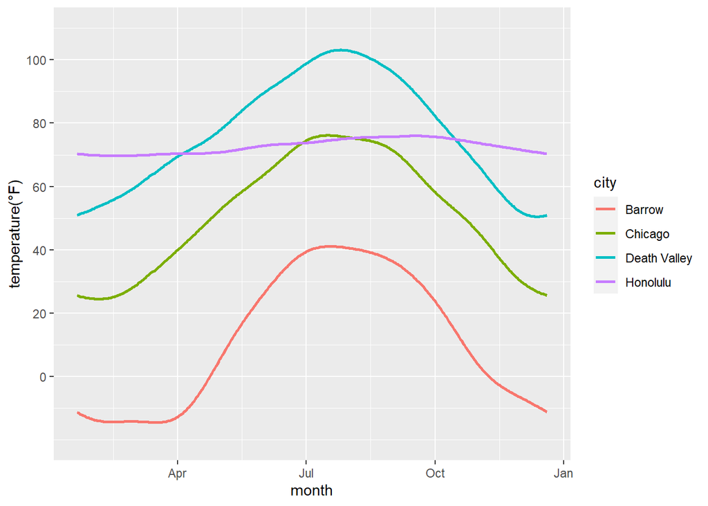

```r
ggplot(temp) +
  geom_line(aes(x = date, y = temperature, group = city, col = city),size = 1) +
  labs(x = "month", y= "temperature(°F)") +
  scale_x_continuous(label = c("Jan","Apr","Jul","Oct","Jan")) +
  scale_y_continuous(
    limits = c(-20,110),
    breaks = c(0,20,40,60,80,100)
    )
```

2. Using the `group_by` + `summarise` pattern, compute the mean temperature for each month in each city.

```r
temp %>%
  group_by(city,month) %>%
  summarise(mean_temperature = mean(temperature))
```

```
## # A tibble: 48 × 3
## # Groups:   city [4]
##    city   month mean_temperature
##    <chr>  <chr>            <dbl>
##  1 Barrow 01              -13.4
##  2 Barrow 02              -14.2
##  3 Barrow 03              -12.6
##  4 Barrow 04                1.78
##  5 Barrow 05               21.1
##  6 Barrow 06               35.6
##  7 Barrow 07               40.8
##  8 Barrow 08               39
##  9 Barrow 09               32.1
## 10 Barrow 10               17.2
## # … with 38 more rows
```

3. Using the data generated in (b), Make a version of Figure 2.4 using a tile mark (`geom_tile`). Try either (i) adding the `scale_fill_viridis_c(option = "magma")` scale to match the color scheme from the reading or (ii) adding coord_fixed()` to make sure the marks are squares, not rectangles.

```r
average_temp <- temp %>%
  group_by(city,month) %>%
  summarise(mean_temperature = mean(temperature))
average_temp
```

```
## # A tibble: 48 × 3
## # Groups:   city [4]
##    city   month mean_temperature
##    <chr>  <chr>            <dbl>
##  1 Barrow 01              -13.4
##  2 Barrow 02              -14.2
##  3 Barrow 03              -12.6
##  4 Barrow 04                1.78
##  5 Barrow 05               21.1
##  6 Barrow 06               35.6
##  7 Barrow 07               40.8
##  8 Barrow 08               39
##  9 Barrow 09               32.1
## 10 Barrow 10               17.2
## # … with 38 more rows
```

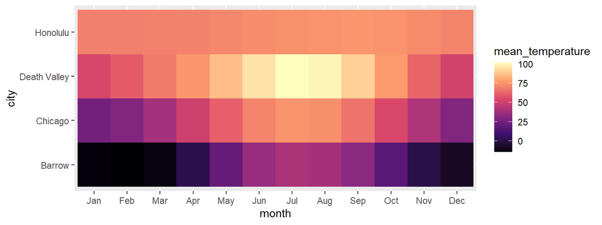

```r
ggplot(average_temp,aes(month,city,fill=mean_temperature)) +
  geom_tile() +
  scale_fill_viridis_c(option ="magma") +
  scale_x_discrete(
    #breaks = c(1,2,3,4,5,6,7,8,9,10,11,12),
    labels = c("01"="Jan","02"="Feb","03"="Mar","04"="Apr","05"="May","06"="Jun","07"="Jul","08"="Aug","09"="Sep","10"="Oct","11"="Nov","12"="Dec")
    )
```

4. Compare and contrast the two displays. What types of comparisons are easier to make / what patterns are most readily visible using Figure 2.3 vs. Figure 2.4, and vice versa?

For Figure 2.3, we can easily get precise information about how the temperature change over time for each city.Therefore, with the help of it, we know the variation through the year for each city. At the same time, as a line chart, we can obtain more accurate temperature at any point in any city.

Figure 2.4 shows the mean temperature of each month in each city. In this heat map, mean temperature is presented in intuitive colors. People can know which month’s average temperature is higher. Also, because of the intuition of colors, we can tell in which city the average temperature through the whole year is higher.

To sum up, Figure 2.3 is more precise, clearly showing the trend through the year. Figure 2.4 is more intuitive, focusing on the average temperature. Our choice depends on the data we want to visualize and the way we want people to understand these data.

## Soccer code review

1. Soccer Code Review This exercise asks you to conduct an imaginary code review. These are often used in data science teams to,
   - Catch potential bugs
   - Make sure code is transparent to others
   - Create a shared knowledge base

   It is important to be perceptive but friendly.
   - Can the code be made more compact?
   - Are there visual design choices / encodings that could be refined?
   - If your colleague did something well, say so!

   They can also be a great way to learn new functions and programming patterns. Unlike standard code-reviews, I ask you to give an example implementing your recommendations.

   Specifically, in this review, suppose you are working on a sports blog, and your colleague is soccer interested in which teams won the most games in a few European leagues over the last few years. They have written the code below. Provide your code review as a set of bullet points, and include code giving an example implementation of your ideas. The original data are from [this link](https://www.kaggle.com/slehkyi/extended-football-stats-for-european-leagues-xg).

   ```r
   win_props <- read_csv("https://raw.githubusercontent.com/krisrs1128/stat479_s22/main/exercises/data/understat_per_game.csv") %>%
     group_by(team, year) %>%
     summarise(n_games = n(), wins = sum(wins) / n_games)
   ```

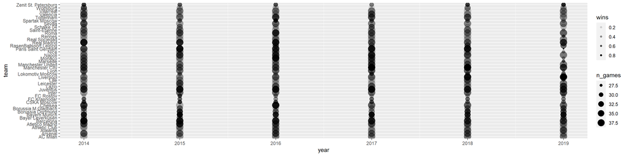

   An example figure for code review.

   ```r
   best_teams <- win_props %>%
     ungroup() %>%
     slice_max(wins, prop = 0.2) %>%
     pull(team)

   win_props %>%
     filter(team %in% best_teams) %>%
     ggplot(aes(x=year,y=team,fill=)) +
     geom_point(aes(year, team, size = n_games, alpha = wins))
   ```

```r
win_props <- read_csv("https://raw.githubusercontent.com/krisrs1128/stat479_s22/main/exercises/data/understat_per_game.csv") %>%
  group_by(team, year) %>%
  summarise(n_games = n(), wins = sum(wins) / n_games)
win_props
```

```
## # A tibble: 684 × 4
## # Groups:   team [168]
##    team      year n_games  wins
##    <chr>    <dbl>   <int> <dbl>
##  1 AC Milan  2014      38 0.342
##  2 AC Milan  2015      38 0.395
##  3 AC Milan  2016      38 0.474
##  4 AC Milan  2017      38 0.474
##  5 AC Milan  2018      38 0.5
##  6 AC Milan  2019      38 0.5
##  7 Alaves    2016      38 0.368
##  8 Alaves    2017      38 0.395
##  9 Alaves    2018      38 0.342
## 10 Alaves    2019      38 0.263
## # … with 674 more rows
```

```r
best_teams <- win_props %>%
      ungroup() %>%
      slice_max(wins, prop = 0.2) %>%
      pull(team)
best_teams
```

```
##   [1] "Liverpool"              "Manchester City"        "Manchester City"
##   [4] "Bayern Munich"          "Paris Saint Germain"    "Bayern Munich"
##   [7] "Barcelona"              "Chelsea"                "Juventus"
##  [10] "Liverpool"              "Monaco"                 "Paris Saint Germain"
##  [13] "Real Madrid"            "Bayern Munich"          "Barcelona"
##  [16] "Juventus"               "Juventus"               "Paris Saint Germain"
##  [19] "Paris Saint Germain"    "Real Madrid"            "Atletico Madrid"
##  [22] "Barcelona"              "Barcelona"              "Juventus"
##  [25] "Napoli"                 "Real Madrid"            "Roma"
##  [28] "Bayern Munich"          "Bayern Munich"          "Spartak Moscow"
##  [31] "Zenit St. Petersburg"   "Paris Saint Germain"    "Bayern Munich"
##  [34] "Borussia Dortmund"      "Barcelona"              "Chelsea"
##  [37] "Juventus"               "Juventus"               "Manchester City"
##  [40] "Napoli"                 "Real Madrid"            "Tottenham"
##  [43] "Borussia Dortmund"      "CSKA Moscow"            "Zenit St. Petersburg"
```

[output cut: 35 more lines]

The code above calculate the rate of winning for each team, choose the top 20% and plot a scatter plot for them. I think we can redesign the size of this plot and labels to make it more intuitive.

```r
win_props <- read_csv("https://raw.githubusercontent.com/krisrs1128/stat479_s22/main/exercises/data/understat_per_game.csv") %>%
  group_by(team, year) %>%
  summarise(total_games = n(), wins_rate = sum(wins) / total_games)
```

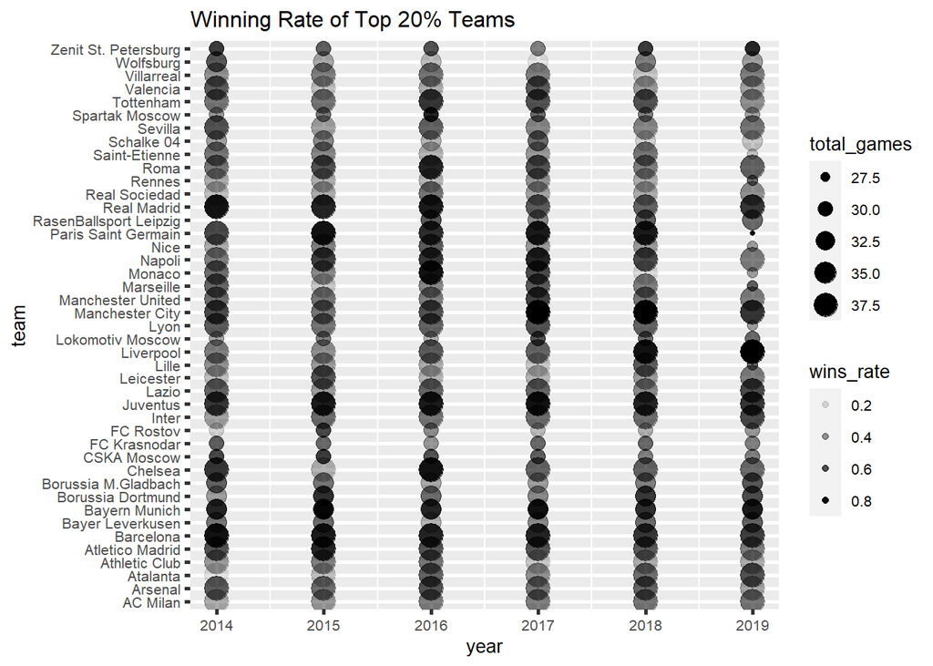

```r
best_teams <- win_props %>%
  ungroup() %>%
  slice_max(wins_rate, prop = 0.2) %>%
  pull(team)

win_props %>%
  filter(team %in% best_teams) %>%

  ggplot(aes(year, team, size = total_games, alpha = wins_rate)) +
  geom_point() +
  theme(text = element_text(size=10),element_line(size=1)) +
  labs(title = "Winning Rate of Top 20% Teams")
```

## Visual Redesign

Visual Redesign In this exercise, you will find a visualization you have made in the past and redesign it using the skills you have learned in this course.

```
a. Identify one of your past visualizations for which you still have data.
Include a screenshot of this past visualization.
```

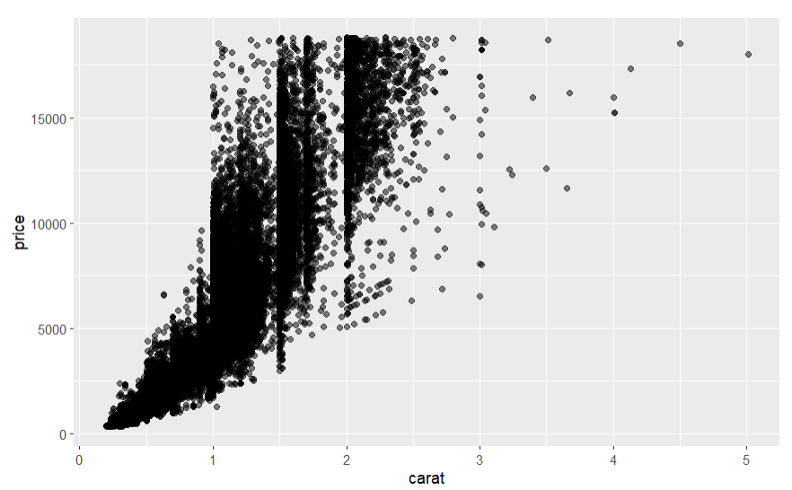

Diamond

```
  b. Comment on the main takeaways from the visualization and the graphical
  relationships that lead to that conclusion. Is this takeaway consistent with
  the intended message? Are there important comparisons that you would like to
  highlight, but which are harder to make in the current design?

  According to the screenshot, the main takeaway is the relationship between
  price of diamonds and the carat of diamonds. And there is a clear positive
  relation between those two values. However, the picture does not fully show
  the impact of other factors on the price, which may be the reason of those
  obvious unusual data in certain range of carat.

c. Comment on the legibility of the original visualization. Are there aspects
of the visualization that are cluttered or difficult to read?

Yes. We can see that at certain points, like carat=1, carat=1.5, data points are
clustered together.And even for diamonds at same mass, the variance of price
is huge. So we can try to find the relation between price and other factors
to find out the reasons for this phenomenon.

d. Propose and implement an alternative design. What visual tasks do you
prioritize in the new design? Did you have to make any trade-offs? Did you
make any changes specifically to improve legibility.

For this implement, I want to find out the influence of cut, color and clarity
on the relationship between price and carat.
```

```r
diamonds
```

```
## # A tibble: 53,940 × 10
##    carat cut       color clarity depth table price     x     y     z
##    <dbl> <ord>     <ord> <ord>   <dbl> <dbl> <int> <dbl> <dbl> <dbl>
##  1  0.23 Ideal     E     SI2      61.5    55   326  3.95  3.98  2.43
##  2  0.21 Premium   E     SI1      59.8    61   326  3.89  3.84  2.31
##  3  0.23 Good      E     VS1      56.9    65   327  4.05  4.07  2.31
##  4  0.29 Premium   I     VS2      62.4    58   334  4.2   4.23  2.63
##  5  0.31 Good      J     SI2      63.3    58   335  4.34  4.35  2.75
##  6  0.24 Very Good J     VVS2     62.8    57   336  3.94  3.96  2.48
##  7  0.24 Very Good I     VVS1     62.3    57   336  3.95  3.98  2.47
##  8  0.26 Very Good H     SI1      61.9    55   337  4.07  4.11  2.53
##  9  0.22 Fair      E     VS2      65.1    61   337  3.87  3.78  2.49
## 10  0.23 Very Good H     VS1      59.4    61   338  4     4.05  2.39
## # … with 53,930 more rows
```

```r
library(patchwork)
```

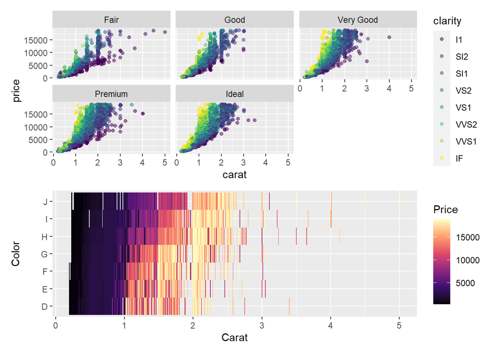

```r
p1 <- ggplot(diamonds,aes(x=carat,y=price,color = clarity)) +
  facet_wrap(~ cut) +
  geom_point(alpha = 0.5)

p2 <- ggplot(diamonds,aes(x=carat,y=color,fill = price)) +
  geom_tile() +
  scale_fill_viridis_c(option = 'magma') +
  labs(x="Carat",y="Color",fill="Price")

p1/p2
```

## Antibiotcs Comparison

````
```r
antibiotic <- read_csv("https://uwmadison.box.com/shared/static/5jmd9pku62291ek20lioevsw1c588ahx.csv")
```

```
## Rows: 972 Columns: 7
## ── Column specification ────────────────────────────────────────────────────────
## Delimiter: ","
## chr (4): species, sample, ind, antibiotic
## dbl (3): value, time, svalue
##
## ℹ Use `spec()` to retrieve the full column specification for this data.
## ℹ Specify the column types or set `show_col_types = FALSE` to quiet this message.
```

```r
antibiotic
```

```
## # A tibble: 972 × 7
##    species  sample value ind    time svalue antibiotic
##    <chr>    <chr>  <dbl> <chr> <dbl>  <dbl> <chr>
##  1 Unc05qi6 D1         0 D         1   NA   Antibiotic-free
##  2 Unc05qi6 D2         0 D         2   NA   Antibiotic-free
##  3 Unc05qi6 D3         0 D         3    0   Antibiotic-free
##  4 Unc05qi6 D4         0 D         4    0   Antibiotic-free
##  5 Unc05qi6 D5         0 D         5    0   Antibiotic-free
##  6 Unc05qi6 D6         0 D         6    0.2 Antibiotic-free
##  7 Unc05qi6 D7         0 D         7    0.2 Antibiotic-free
##  8 Unc05qi6 D8         1 D         8    0.2 Antibiotic-free
##  9 Unc05qi6 D9         0 D         9    0.2 Antibiotic-free
## 10 Unc05qi6 D10        0 D        10    0.2 Antibiotic-free
## # … with 962 more rows
```

For each approach, describe,

  * One type of visual comparison for which the visualization is well-suited.

  * One type of visual comparison for which the visualization is poorly-suited.

Make sure to explain your reasoning.

a. Approach 1
````

It’s easy for people to compare the trend of different species and different antibiotics under different conditions. As a line chart, this approach focus on the value change in different samples, which make comparison between samples very intuitive.

However, because of the fixed y-axis range, when the absolute value is very small in certain samples, we can hardly get detailed information about them. That’s the cost of the convenient comparison.

```
b. Approach 2
```

Approach 2 is a group of heat map. Our attention will be attracted to those darker areas, which represent higher values than other times and samples. So this approach emphasizes outstanding values, and we can easily know under which conditions the values will be higher.

As the cost of that, we are unable to learn the exact value of each data point. Different colors represent different range of value, so the detailed values are hidden.

```
c. Approach 3
```

For this approach, data are divided into three line chart according to their sample. So we can easily know how the value of different species change over time in each sample. And comparison between different species in the same sample are explicit.

However, because the data are divided into three groups. Comparison between different samples from the same species at the same time are difficult.

[output not shown]

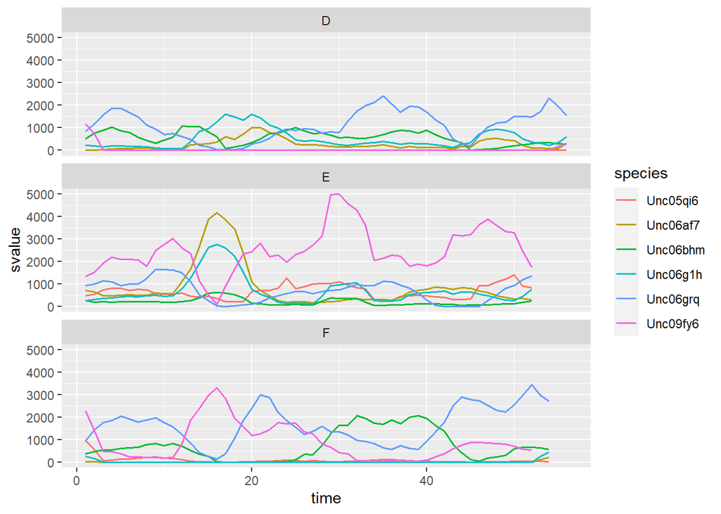

```r
ggplot(antibiotic) +
  geom_line(aes(x=time,y=svalue,group=species,col = species),size = 0.7) +
  labs(x = "time",y="svalue")+
  facet_wrap(~ind,nrow = 3)
```

## Homelessness

Homelessness Take a static screenshot from any of the visualizations in this [article](https://www.theguardian.com/us-news/ng-interactive/2017/dec/20/bussed-out-america-moves-homeless-people-country-study), and deconstruct its associated visual encodings.

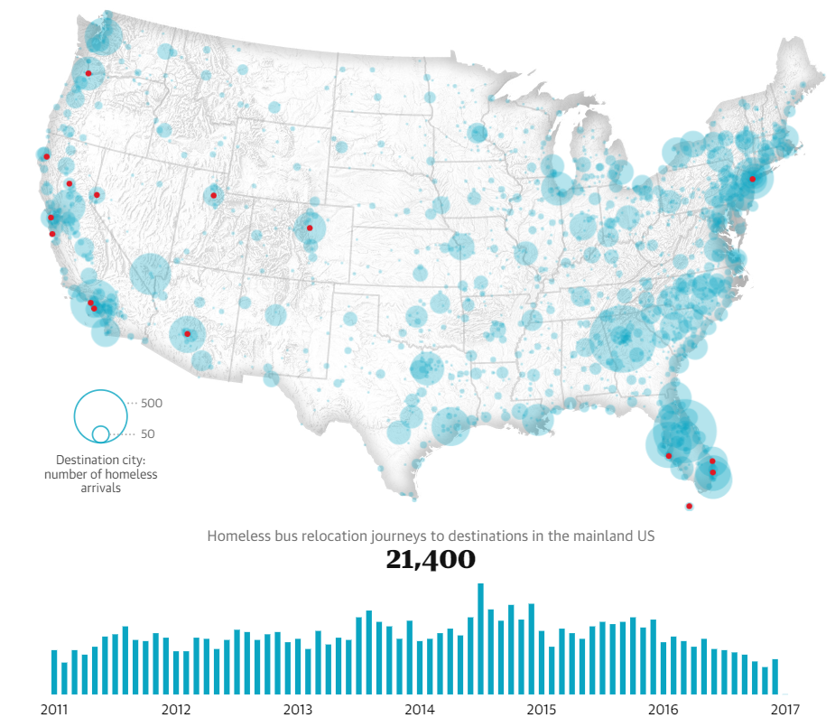

homelessness